# Superficie sembrada y cosechada por campaña

## 1 Objetivo

Este informe describe la evolución de la superficie sembrada y cosechada de Girasol, Maíz, Soja total y Trigo total. Los gráficos comparan ambas superficies en hectáreas a lo largo de las campañas disponibles.

## 2 Datos y metodología

La fuente es `Rendimientos_decada.xlsx`, en la hoja `rendimiento`. Cada registro corresponde a una observación geográfica. Para comparar las campañas, se suman las superficies por cultivo y campaña.

Las celdas vacías y los valores `NA`, `N/A` y `SD` se tratan como faltantes, no como cero. Cuando una campaña tiene observaciones válidas y faltantes, se suman las observaciones disponibles; si todas faltan, el total queda sin dato. Los gráficos dejan un corte en las series cuando no hay un total disponible.

La base incluye 34.224 registros en 56 campañas, desde 1969/70 hasta 2024/25. Se identifican 4 cultivos.

En los registros de origen hay 0 valores faltantes de superficie sembrada y 1 de superficie cosechada.

## 3 Resumen por cultivo

La tabla presenta promedios de los totales por campaña. La campaña de máxima cosecha se calcula entre aquellas con superficie cosechada disponible.

Superficie agregada y promedio por campaña

| Cultivo | Campañas con datos | Promedio sembrada (ha) | Promedio cosechada (ha) | Máxima cosechada (ha) | Campaña de máxima cosecha |
| --- | --- | --- | --- | --- | --- |
| Girasol | 55 | 1.845.322 | 1.765.943 | 3.845.370 | 1998/99 |
| Maíz | 55 | 3.864.295 | 3.074.744 | 7.102.988 | 2023/24 |
| Soja total | 55 | 7.960.202 | 7.753.810 | 17.004.801 | 2015/16 |
| Trigo total | 56 | 5.271.645 | 4.978.919 | 7.237.000 | 1982/83 |

En promedio, **Soja total** presenta la mayor superficie sembrada por campaña. La cosecha máxima del período se observa en **Soja total**, durante la campaña **2015/16**.

## 4 Girasol

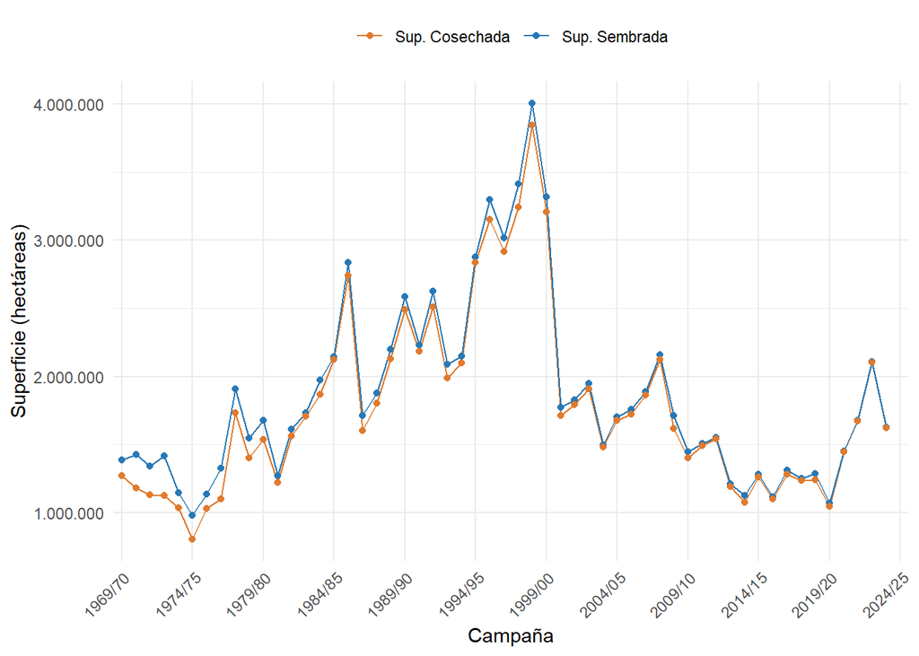

## 5 Maíz

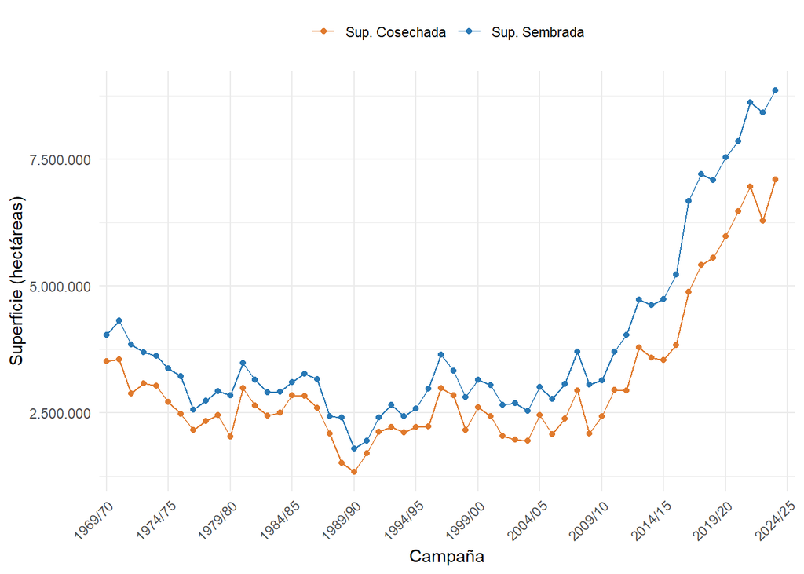

## 6 Soja total

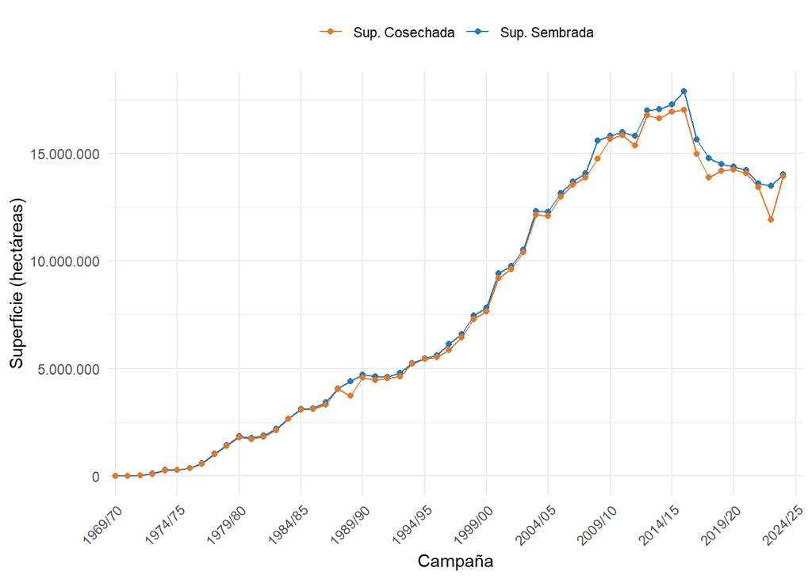

## 7 Trigo total

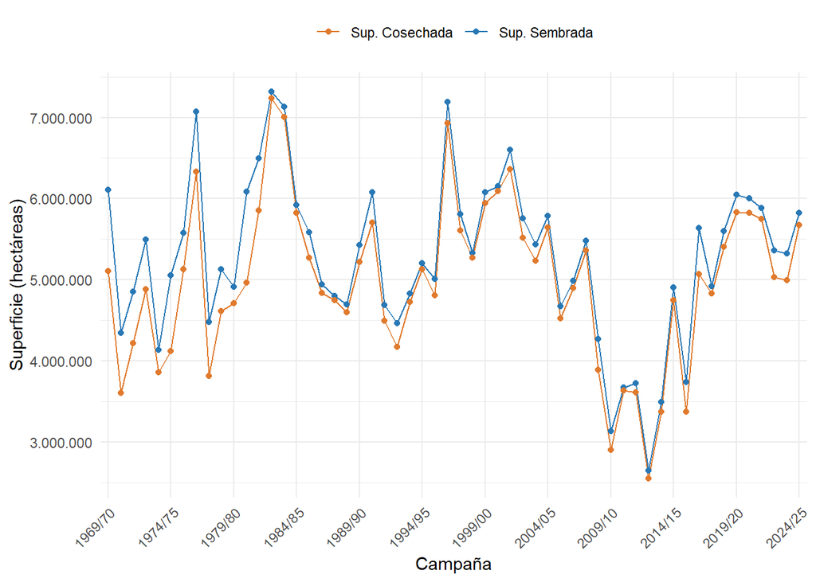